# Assignment 3 ST302

your name

2023-03-30

```r
#install.packages(c("RColorBrewer", "gapminder", "ggrepel", "colorspace","ISLR2"))
#install.packages(c("cvd_emulator"))
library(tidyverse)
library(gapminder)
library(ggrepel)
library(colorspace)
library(ISLR2)
library(ggplot2)
#library(cvd_emulator)
```

## Question 1.

1. Here is figure 6.27 in the notes (shown below), and beside it how the figure appears in the most common type of colour blindness (Deuteranope). Is the choice of colours in the original plot successful for colour blind people?

Wheats RGB Colour Code is: (227,199,166) Blue’s Colour Code is: (0,0,256)

The colours in the plot are is successful for colorblind people.

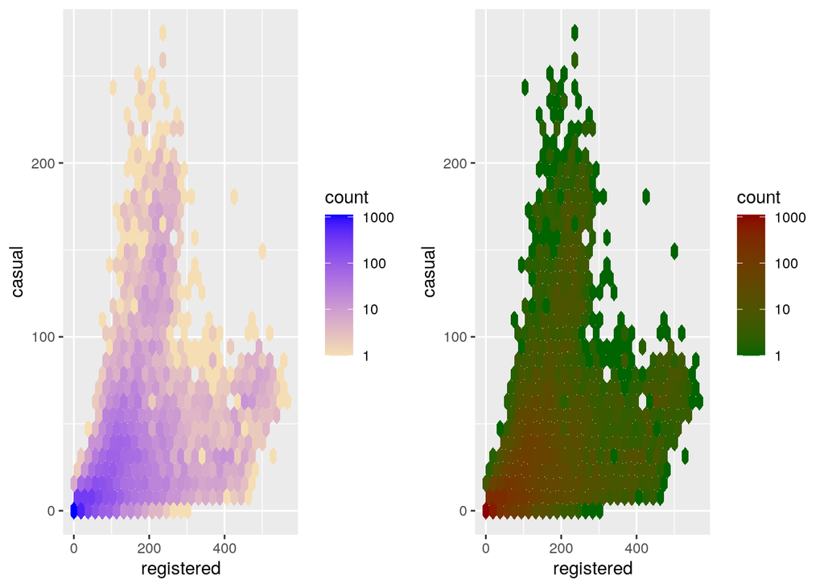

```r
p <- ggplot(data=Bikeshare, aes(x=registered, y=casual))


require(gridExtra) #Plot 1 is how it normally looks, Plot 2 is how the colorblind see it.
plot1 <- p +  geom_hex() + scale_fill_gradient(low = "wheat", high = "blue" ,trans="log10")
plot2 <- p + geom_hex() + scale_fill_gradient(low = "darkgreen", high = "darkred", trans = "log10")
grid.arrange(plot1, plot2, ncol=2)
```

```r
cvd_emulator(here::here("hwk", "figs", "q1b.png"), overwrite=TRUE)
```

```
## Convert deutan          -> /users/students/20325583/ST302/hwk/figs/deutan_q1b.png
## Convert protan          -> /users/students/20325583/ST302/hwk/figs/protan_q1b.png
## Convert tritan          -> /users/students/20325583/ST302/hwk/figs/tritan_q1b.png
## Convert desaturate      -> /users/students/20325583/ST302/hwk/figs/desaturate_q1b.png
```

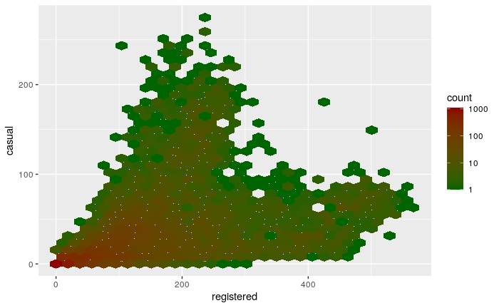

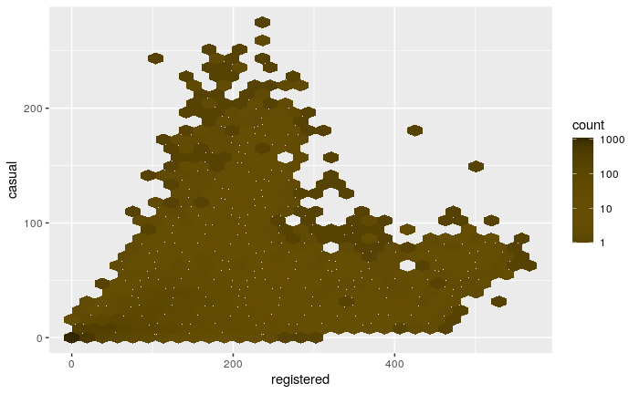

```r
knitr::include_graphics(here::here("hwk", "figs", "q1b.png"))
knitr::include_graphics(here::here("hwk", "figs", "deutan_q1b.png"))
```

B. Explain why this plot does not work for a color blind person.

This plot may not work for a color blind person as dark green and dark red are problematic colors for people with Deuteranope. It is very common to mix up both light shades of red and green, and dark shades of red and green. Even by looking at the plot, it is fairly challenging to differentiate between some of the shades of red and green in the plot.